# Aufgabenblatt 3

## Statistik für Wirtschaftsinformatiker, Übung, HTW Berlin

### Martin Spott, Michael Heimann

Stand: 03.05.2023

## Wiederholung

- Was ist eine Primärerhebung? Was ist eine Sekundärerhebung? Nenne für jede der beiden Erhebungsarten zwei Vorteile, die sie gegenüber der anderen hat.
- Was versteht man unter absoluter bzw. relativer Häufigkeit?
- Warum sind Balkendiagramme im Allgemeinen Kreisdiagrammen vorzuziehen, um Häufigkeitsverteilungen zu visualisieren?
- Was ist ein Histogramm? Was ist der Unterschied zwischen einem Histogramm und dem Balkendiagramm einer Häufigkeitstabelle?
- Wie wählt man die Gruppen in einem Histogramm?
- Was ist eine kumulierte Verteilung?

## RMarkdown

Der letzten Aufgabe von Aufgabenblatt 2 folgend informiere dich über *RMarkdown* und öffne die Datei `aufgaben_sta_3.Rmd` in RStudio. Dies ist die Quelldatei, aus der in RStudio dieses Übungsblatt generiert wurde. Wir werden zusammen in der Übung sicherstellen, dass alle die Datei in ein HTML- oder PDF-Dokument übersetzen können.

Bis auf die Handzeichnung eines Balkendiagrammes können alle Aufgaben (textuell oder in R) in diesem Dokument beantwortet werden. So können die Übungsaufgaben dokumentiert werden inklusive persönlicher Kommentare, die beim Wiederholen für die Klausur helfen. Weiterhin werden kommende Übungsblätter auf dem R-Code vorheriger Blätter aufbauen. Speichere also diese Datei regelmäßig während und nach der Bearbeitung.

## Aufgabe 3.1 (Häufigkeiten)

Ein Hersteller von Smartphonehüllen bietet seine Produkte in verschiedenen Farben an: *hellweiß*, *schwarzmetallic*, *limette*, *orange* und *rot*. Am Eingang zur IFA 2015 wurden zufällig ausgewählte Besucher nach ihrer bevorzugten Farbe befragt. Die nachfolgende Tabelle fasst die Ergebnisse der Befragung zusammen.

```r
library(knitr)
Farbe <- c("hellweiß", "schwarzmetallic", "limette", "orange", "rot")
Nennung <- c(130, 104, 325, 455, 286)
huellen_farben <- data.frame(Farbe, Nennung)
kable(huellen_farben)
```

| Farbe | Nennung |
| --- | --- |
| hellweiß | 130 |
| schwarzmetallic | 104 |
| limette | 325 |
| orange | 455 |
| rot | 286 |

1. Um was für eine Tabelle handelt es sich?
   - Häfuigkeitstabelle
2. Fertige ein entsprechendes Balkendiagramm auf Papier an.
3. Informiere dich über den R-Befehl `barplot()`.?
   - `barplot(height, ...)`
4. Erstelle in R analog zu b) ein Balkendiagramm. Die notwendigen Beschriftungen (Achsen usw.) nicht vergessen!

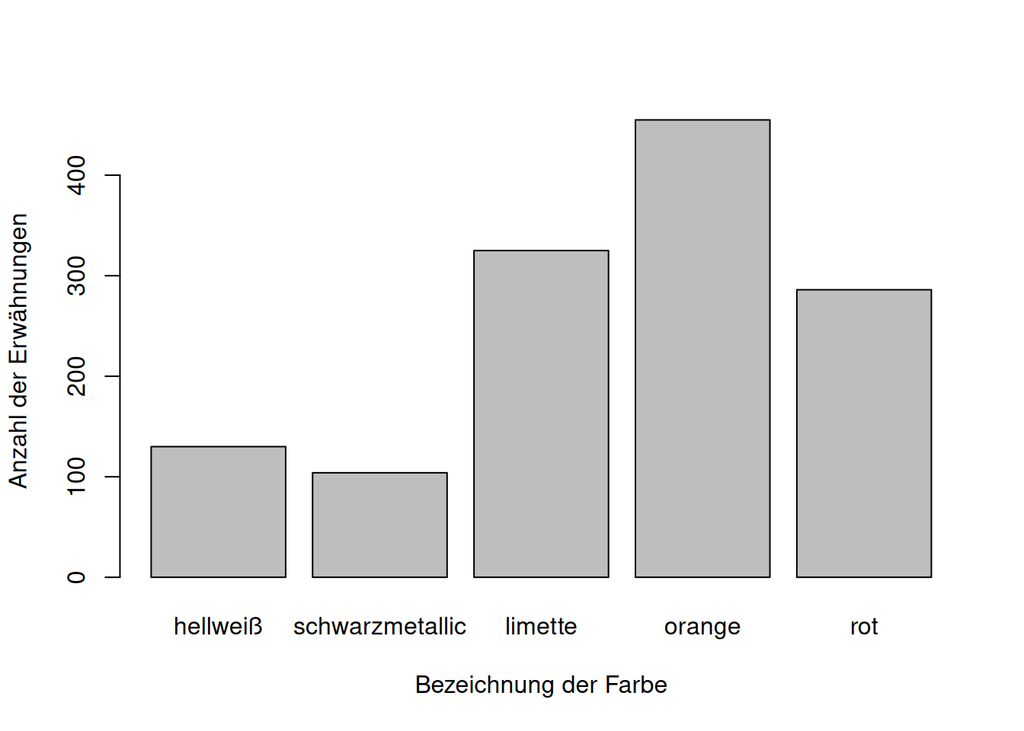

```r
barplot(height = huellen_farben$Nennung,
        names.arg = huellen_farben$Farbe,
        xlab = "Bezeichnung der Farbe",
        ylab = "Anzahl der Erwähnungen")
```

5. Angenommen, das Unternehmen möchte insgesamt eine Million Hüllen herstellen, wieviel Stück sollten dann von jeder Farbe produziert werden?

```r
summe_antworten <- sum(huellen_farben$Nennung)
summe_antworten
```

```
## [1] 1300
```

```r
proz_farben <- c(huellen_farben$Nennung / summe_antworten)
huellen_farben$proz <- proz_farben
huellen_farben$Anz_Million <- c(huellen_farben$proz * 1000000)
huellen_farben
```

```
##             Farbe Nennung proz Anz_Million
## 1        hellweiß     130 0.10      100000
## 2 schwarzmetallic     104 0.08       80000
## 3         limette     325 0.25      250000
## 4          orange     455 0.35      350000
## 5             rot     286 0.22      220000
```

```r
kable(huellen_farben)
```

| Farbe | Nennung | proz | Anz_Million |
| --- | --- | --- | --- |
| hellweiß | 130 | 0.10 | 100000 |
| schwarzmetallic | 104 | 0.08 | 80000 |
| limette | 325 | 0.25 | 250000 |
| orange | 455 | 0.35 | 350000 |
| rot | 286 | 0.22 | 220000 |

Bei den folgenden Aufgaben arbeiten wir mit dem Applewood-Datensatz von 2011 aus dem Buch *Statistical Techniques in Business and Economics* von Lind/Marchal/Wathen, der aus Autokäufen bei einem Händler namens Applewood resultierte. Die Datei `Applewood_2011.csv` kann von Moodle heruntergeladen werden. Sie enthält folgende Variablen:

- *Age*: Lebensalter des Käufers in Jahren
- *Profit*: Gewinn aus dem Verkauf
- *Location*: Niederlassung des Autohauses
- *Vehicle.Type*: Fahrzeugtyp
- *Previous*: Anzahl der vorausgegangenen Käufe bei Applewood

## Aufgabe 3.2 (Applewood)

Importiere die Datei in R und verschaffe dir zunächst einen Überblick über Umfang und Struktur des Datensatzes. Hierzu stehen unter anderen die folgenden R-Befehle zur Verfügung: `read.csv2()`, `names()`, `dim()`, `str()`, `head()` und `View()`. Beachte, dass `read.csv2()` nur eine spezielle Version von `read.table()` ist.

```r
applewood <- read.csv2("Applewood_2011.csv", header = TRUE)
names(applewood)
```

```
## [1] "Age"          "Profit"       "Location"     "Vehicle.Type" "Previous"
```

```r
dim(applewood)
```

```
## [1] 180   5
```

```r
str(applewood)
```

```
## 'data.frame':    180 obs. of  5 variables:
##  $ Age         : int  21 23 24 25 26 27 27 28 28 29 ...
##  $ Profit      : int  1387 1754 1817 1040 1273 1529 3082 1951 2692 1206 ...
##  $ Location    : chr  "Tionesta" "Sheffield" "Sheffield" "Sheffield" ...
##  $ Vehicle.Type: chr  "Sedan" "SUV" "Hybrid" "Compact" ...
##  $ Previous    : int  0 1 1 0 1 1 0 1 0 0 ...
```

```r
head(applewood)
```

```
##   Age Profit  Location Vehicle.Type Previous
## 1  21   1387  Tionesta        Sedan        0
## 2  23   1754 Sheffield          SUV        1
## 3  24   1817 Sheffield       Hybrid        1
## 4  25   1040 Sheffield      Compact        0
## 5  26   1273      Kane        Sedan        1
## 6  27   1529 Sheffield        Sedan        1
```

```r
View(applewood)
```

1. Was sind die Merkmalsträger? Was ist die Grundgesamtheit?
   - Merkmalsträger: einzelner Verkauf
   - Grundgesamtheit: Käufe
2. Betrachte die Merkmale hinsichtlich ihrer Skalen und ordne den Merkmalen die Begriffe qualitativ, quantitativ, diskret und stetig sinnvoll zu. Falls es sich um ein quantitatives Merkmal handelt, hat dieses wenige oder viele Merkmalsausprägungen in den Beobachtungen?
   - Age: quantiativ, stetig, viele Ausprägungen
   - Profit: quantitativ, stetig, viele Ausprägungen
   - Location: qualitativ, diskret
   - Vehicle.Type: qualitativ, diskret,
   - Previous: quantitativ, stetig, wenige Ausprägungen

## Aufgabe 3.3 (Applewood)

Informiere dich über die R-Befehle `table()`, `prop.table()` und `cumsum()`.

1. Erzeuge eine Häufigkeitstabelle für die Variable *Previous* (= Anzahl der vorausgegangenen Verkäufe). Die Tabelle soll die folgenden Informationen enthalten:
   - Ausprägungen des Merkmals *Previous*
   - absolute Häufigkeit
   - relative Häufigkeit (gerundet auf 3 Stellen hinter dem Komma)
   - kumulierte absolute Häufigkeit
   - kumulierte relative Häufigkeit (gerundet auf 3 Stellen hinter dem Komma).

   Benutze für die Tabelle einen *Data Frame* in R. Aufgabe 1 zeigt ein Beispiel dafür, wie ein Data Frame mit `data.frame()` erzeugt werden kann.
2. Erzeuge ein Balkendiagramm für die Ausprägungen der Variable *Previous*.

## Aufgabe 3.4 (Applewood)

Informiere dich über den R-Befehl `hist()`, um Histogramme zu erzeugen.

1. Erzeuge ein Histogramm des Merkmals *Profit* mit dem R-Befehl `hist()`. Beschrifte alle Axen und gib dem Diagramm eine Überschrift.
2. Füge dem Befehl `hist()` aus a) das Argument `freq = FALSE` zu. Vergleiche das erzeugte Histogramm mit dem aus a). Was ist der Unterschied?
3. Variiere die Anzahl der Gruppen mit dem Argument `breaks` und vergleiche die resultierenden Histogramme.
4. Benutze das Argument `breaks`, um folgende Gruppen zu spezifizieren: (0, 250], (250, 500], … (2750, 3000], (3000, 3500]. Erzeuge damit ein Histogramm and interpretiere die Höhe der Balken. Wie sind die Höhen der Balken über (2750, 3000] und (3000, 3500] zu vergleichen? Verändere das letzte Intervall von (3000, 3500] zu (3000, 5000]. Erkläre den Unterschied der Ergebnisse.

   Beachte, dass Intervalle wie (0,250] die Null nicht enthalten (runde Klammer), aber 250 schon (eckige Klammer). Wenn R ein Histogramm zeichnet, wird als Standard angenommen, dass die rechte Seite zum Intervall gehört. Das Verhalten kann aber über den Parameter `right = ...` gesteuert werden. Standard ist `right = TRUE`, was man aber auf `right = FALSE` ändern kann, wenn die linke Seite zu den Intervallen gehören soll.
5. Benutze die Funktion `ecdf()`, um die relative kumulierte Häufigkeitsverteilung von *Profit* zu berechnen. Finde heraus, wie man sie mit dem Befehl `plot` als Graphik darstellen kann. Was kann man aus dieser Verteilung ablesen? Gib zwei Beispiele an!

## Aufgabe 3.5 (kumulierte Häufigkeitsverteilung als Polygonzug)

Eine Gruppe von Schweißern wurde im Hinblick auf den Verdienst (Stundenlohn in Euro) untersucht. Die folgende Abbildung visualisiert die Ergebnisse:

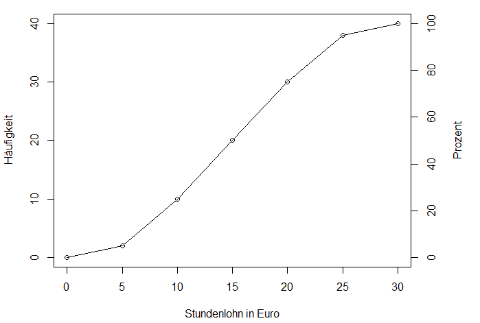

kumulierte Häufigkeitsverteilung als Polygonzug

Beantworte auf der Grundlage dieser Darstellung nachstehende Fragen bzw. vervollständige die Aussagen:

1. Wie viele Personen wurden in die Untersuchung einbezogen?
2. *N* Personen verdienen bis zu 10€ pro Stunde. Bestimme *N*.
3. Rund 75% verdienen bis zu *x* € pro Stunde. Bestimme *x*.
4. 20 der untersuchten Personen verdienen bis zu *y* € pro Stunde. Bestimme *y*.